# Weather and Electricity Demand

NYC and Long Island, 2020–2026

Energy Team: Bikash Bhowmik, Cecilia De La Fuente Chavez, Ellie Wilser, Zaina Hassan

## Data Sources

- **NYISO** 5-minute load data (NYC and Long Island zones)
- **NOAA / NWS** daily weather: temperature and precipitation
- **Time range:** January 2020 to September 2026

| NYISO Zone | NOAA Weather Station |
| --- | --- |
| NYC (Zone J) | LaGuardia Airport |
| NYC (Zone J) | Central Park |
| Long Island (Zone K) | Islip Airport |

## Entity Relationship Diagram

```
erDiagram zone ||--o{ weather_station : "has" zone ||--o{ daily_electricity_load : "has" weather_station ||--o{ daily_weather : "records"
zone {
    int ptid PK
    text nyiso_zone_name
    text noaa_zone_name
}
weather_station {
    text station_id PK
    text noaa_station_name
    int ptid FK
}
daily_electricity_load {
    int ptid PK, FK
    date load_date PK
    numeric avg_load
}
daily_weather {
    text station_id PK, FK
    date obs_date PK
    numeric prcp
    numeric tmax
    numeric tmin
}
```

## NYISO Load Data

**What I accomplished:**

- Automated downloading monthly ZIP files containing electricity load data.
- Extracted and read the CSV files without manually opening each archive.
- Filtered the data and combined the relevant records into one dataframe.
- Aggregated five-minute observations into daily average electricity load.
- Checked for missing dates and exported the final dataset to CSV.

Output: nyiso_daily_average_load.csv

## NYISO Code Base 1

1. `map_dfr()` — Automate and combine

```
all_data <- map_dfr(months, function(month) {
  # Download and open monthly ZIP
  # Read CSV files
  # Filter for the selected zones
})
```

- Loops through the months in the study period.
- Processes each month’s files and combines the resulting rows into one dataframe.
- Avoids having to download, open, and merge every file manually.

## NYISO Code Base 2

2. `group_by()` + `summarise()` — Calculate daily averages

```
group_by(Date, Name, PTID) |>
  summarise(
    Daily_Average_Load = mean(Load, na.rm = TRUE),
    .groups = "drop"
  )
```

- Groups five-minute observations by date and electricity zone.
- Calculates the average load for each group, ignoring missing load values.
- Produces one daily average per date and zone represented in the data.

## NOAA Weather Data Collection

**Source:** National Oceanic and Atmospheric Administration (NOAA)

**Objective:** Examine how weather conditions relate to electricity demand in New York.

- **Weather stations:** LaGuardia Airport, Central Park, and Islip (Long Island)
- **Key observations:** Daily temperature and precipitation
- **Why three stations?** Capture weather differences across the NYC and Long Island region

## NOAA Data Cleaning and Preparation

**Weather data processing in R**

- Organized daily observations and standardized dates
- Checked missing values and calculated average daily temperature
- **Heating Degree Days (HDD):** `max(65 - TAVG, 0)`
- **Cooling Degree Days (CDD):** `max(TAVG - 65, 0)`
- Both use **65°F** as the reference temperature

## Weather and Electricity Demand

**Summer: Cooling demand**

- Hotter days increase air-conditioning use
- Higher CDD indicates greater cooling needs

**Winter: Heating demand**

- Colder days increase heating requirements
- Higher HDD indicates colder conditions

**Integration:** Join NOAA weather observations with NYISO electricity demand data to investigate seasonal patterns and temperature-related associations.

## Electricity Load Over Time

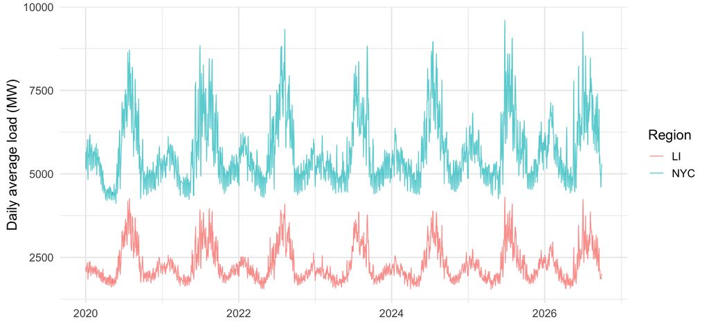

- Clear **summer peaks** in both regions
- NYC averages about **5,655 MW** vs. **2,291 MW** for Long Island

## Seasonal Demand

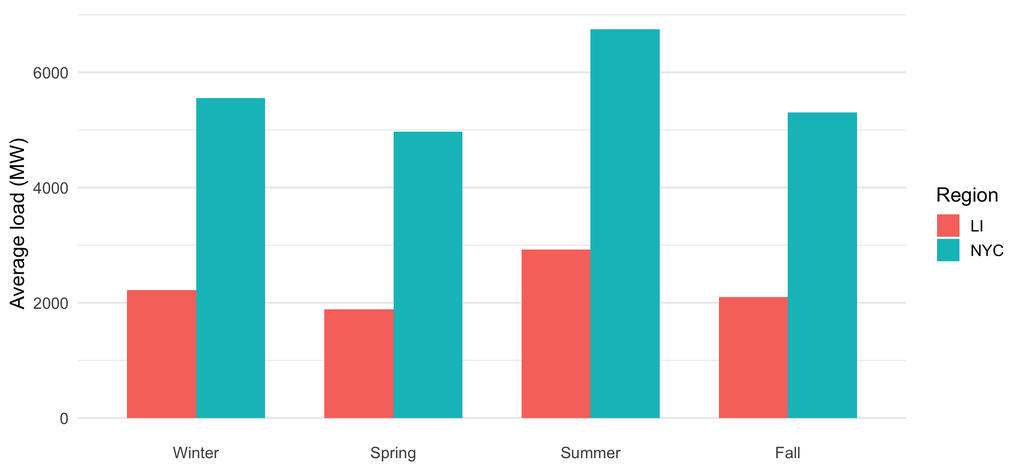

Summer is highest, then winter, fall, spring, in both regions

## Heating and Cooling Degree Days

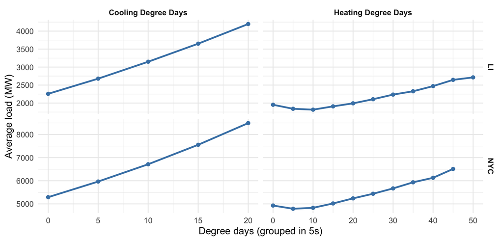

Electricity load increases steadily with cooling degree days in both NYC and Long Island, while heating degree days show a weaker pattern. This comparison highlights and helps explain the higher loads observed during summer.

## Correlations with Daily Load

| Weather variable | Long Island | NYC |
| --- | --- | --- |
| Cooling degree days | **0.908** | **0.854** |
| Heating degree days | -0.332 | -0.251 |
| Precipitation | 0.035 | 0.061 |

- Cooling demand has by far the strongest linear link to load
- Negative HDD correlation reflects the much larger summer peaks, not an absence of winter demand

## Key Takeaways

- Heat is the strongest weather-related indicator of electricity demand.
  - **Temperature:** Demand follows a U-shaped pattern, with sharper increases during hotter conditions.
  - **Extreme demand:** Most high-load outliers occur on hot days.
  - **Precipitation:** Very weak association with electricity demand.
  - **Regional patterns:** NYC has higher overall load, but both regions respond similarly to temperature.

## Limitations and Next Steps

**Limitations**

- Observational: associations, not causation
- Only three weather stations
- 7 missing load dates per zone
- Rain vs. dry ignores intensity and season
- Pearson correlation misses nonlinear patterns

**Next steps**

- More stations, humidity
- Holidays, population, economic indicators
- Statistical modeling of how much variation weather explains

## Thank You

Questions?

github.com/EllieWilser/Project-3